# Where Victoria’s road deaths really happen

What crash *situations* reveal that the official crash categories hide: Victorian Crash Data, 2012 to September 2024

30 October 2026

# Summary

3,244

people killed in Victorian road crashes, 2012–2024

254

deaths every year, and 5,935 serious injuries

59%

of deaths come from just two situations, which make up only 35% of crashes

24×

difference in death rate hidden inside a single official crash category

**Question.** If Victoria could make one kind of road situation safer, which would save the most lives?

**Answer.** Grouping 182,039 police-reported crashes by the *situation* they happened in, rather than the official crash category, shows that deaths are heavily concentrated in two situations:

- **High-speed roads, mostly rural, often a single vehicle:** 20% of crashes but **1,174 deaths (36%)**, about 92 a year.
- **Night-time, often young drivers:** 14% of crashes but **731 deaths (23%)**.

The **most common** situation, city intersections (25% of crashes), is **not** the most deadly. A high-speed rural crash is 3.2 times as likely to kill someone.

**Why it matters.** Victoria’s official crash categories (DCA codes) record *how* a crash happened, such as “head-on” or “ran off the road”, but not the situation. Within the single category “Vehicles from opposing directions”, crashes in one situation killed **132 people per 1,000 crashes** and in another only **5.6**. Counting crashes by category points attention at where crashes are *common*; counting deaths by situation points it at where people *die*.

**What should be done** (Section 6): make high-speed rural roads and night-time driving the two priority situations, keep protecting pedestrians in the inner city, and improve how police record crash conditions.

# 1 Why this question matters

Road-safety resources are limited, so every dollar spent on one location or campaign is a dollar not spent elsewhere. Agencies usually report crashes using the police **Definition for Classifying Accidents (DCA)**, which describes the movement of the vehicles and people involved (rear-end, right-turn, pedestrian struck, off road on a curve…).

That tells you *how* a crash happened but not *what situation the driver was in*: the road, speed limit, time, light, weather, and who was involved. Two crashes with the same DCA code can be completely different events. One is a 50 km/h side-swipe in a city street; the other is a 110 km/h head-on on a dark rural highway.

We asked four questions:

1. What crash **situations** emerge if we let the data group crashes by their conditions?
2. **Which situations cost the most lives**, and where in Victoria do they happen?
3. Do these situations repeat the official categories, or **reveal risk the categories miss**?
4. What does that mean for **where road-safety effort should go**?

# 2 The answer: lives lost in each situation

We grouped all 182,039 crashes into 7 situations using 17 descriptions of the conditions (Section 7 explains how). The grouping didn’t use the outcome, the official category or the location. Those were kept aside so we could test the situations against them.

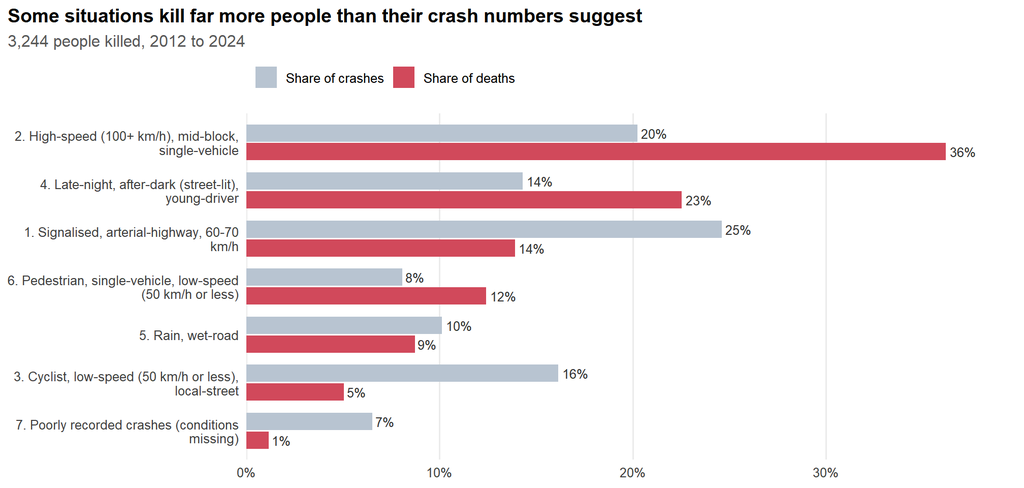

| Situation | Crashes | People killed | Killed per year | Seriously injured per year | Deaths per 1,000 crashes | Share of all deaths |
| --- | --- | --- | --- | --- | --- | --- |
| 2. High-speed (100+ km/h), mid-block, single-vehicle | 36,832 | 1,174 | 92 | 1,457 | 31.9 | 36% |
| 4. Late-night, after-dark (street-lit), young-driver | 26,041 | 731 | 57 | 1,032 | 28.1 | 23% |
| 1. Signalised, arterial-highway, 60-70 km/h | 44,772 | 451 | 35 | 1,394 | 10.1 | 14% |
| 6. Pedestrian, single-vehicle, low-speed (50 km/h or less) | 14,699 | 403 | 32 | 532 | 27.4 | 12% |
| 5. Rain, wet-road | 18,435 | 283 | 22 | 605 | 15.4 | 9% |
| 3. Cyclist, low-speed (50 km/h or less), local-street | 29,385 | 164 | 13 | 764 | 5.6 | 5% |
| 7. Poorly recorded crashes (conditions missing) | 11,875 | 38 | 3 | 152 | 3.2 | 1% |

Three things stand out:

- **Danger is not where crashes are most common.** City intersection crashes (situation 1) are the most frequent, but they kill 10.1 people per 1,000 crashes. High-speed rural crashes kill 31.9, night-time crashes 28.1, and pedestrian crashes 27.4.
- **Speed and darkness are the common thread** in the two deadliest situations. Both are cases where a mistake is harder to survive or harder to see coming.
- **Cyclist crashes are frequent but rarely fatal.** Situation 3 holds 16% of crashes but 5% of deaths. These crashes still cause 764 serious injuries a year.

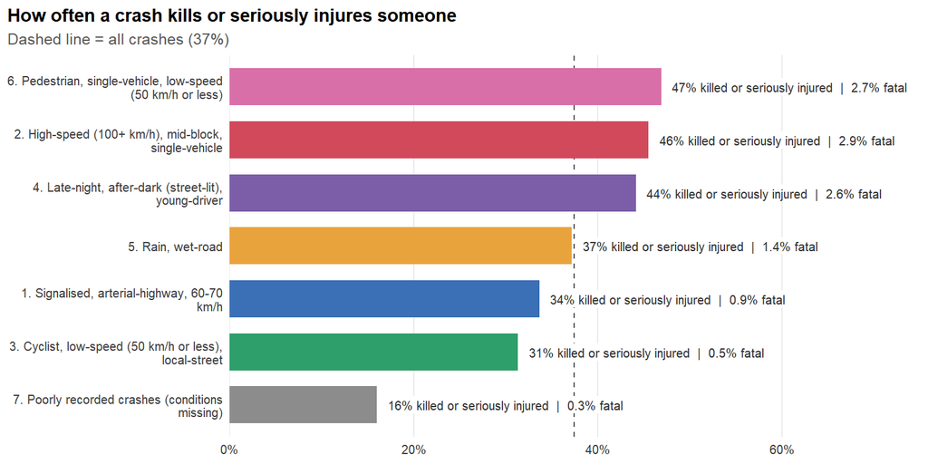

# 3 What the official categories miss

## 3.1 The same official category, a different chance of dying

Every crash in this table has the same official category: “Vehicles from opposing directions”.

| Situation | Crashes | People killed | Deaths per 1,000 crashes | Crashes that killed someone |
| --- | --- | --- | --- | --- |
| 2. High-speed (100+ km/h), mid-block, single-vehicle | 2,475 | 327 | 132.1 | 11.4% |
| 4. Late-night, after-dark (street-lit), young-driver | 3,478 | 106 | 30.5 | 2.7% |
| 5. Rain, wet-road | 2,326 | 52 | 22.4 | 2.0% |
| 1. Signalised, arterial-highway, 60-70 km/h | 9,383 | 108 | 11.5 | 1.1% |
| 3. Cyclist, low-speed (50 km/h or less), local-street | 3,756 | 21 | 5.6 | 0.5% |

Every crash above has the same official label, “Vehicles from opposing directions”. In the **high-speed (100+ km/h), mid-block** situation, **11.4% of them killed someone**. In the **cyclist, low-speed (50 km/h or less)** situation, 0.5% did. A report that only counts crashes by category treats these as one problem. They are very different problems that need different solutions.

## 3.2 Situations and categories only partly overlap

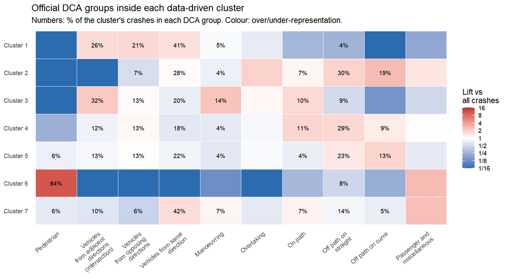

The agreement between our situations and the official categories is low (adjusted Rand index 0.11, where 0 means no agreement and 1 means identical). The one clear exception is **pedestrians**: 84% of situation 6 is the official “Pedestrian” category. When a pedestrian is involved, who was hit defines both groupings. Everywhere else, situations such as rain or darkness cut across every kind of crash movement.

## 3.3 Knowing the situation improves the prediction of deaths

We tested whether the situation tells us anything about the outcome *beyond* the official category, using logistic regression to predict whether a crash was fatal.

| Predicting a fatal crash using… | AUC (0.5 = guessing, 1 = perfect) | Improvement test (p-value) |
| --- | --- | --- |
| DCA group only | 0.682 |  |
| Situation only | 0.671 |  |
| DCA group + situation | 0.735 | <2e-16 |

Adding the situation to the official category improves the prediction of fatal crashes (AUC 0.68 → 0.73), and the improvement is far beyond chance (likelihood-ratio test). **The situation carries life-or-death information that the official category doesn’t record.** The prediction is still far from perfect, because the data doesn’t include impact speed, seatbelt use or traffic volumes.

# 4 The seven situations, told as stories

Each situation is described three ways: its **profile** (calculated from all its crashes), a **typical crash** (the most common value of each condition, combined into one picture) and a **real crash from the data** whose details are most typical of the situation. They’re ordered from most deaths to fewest.

## 4.1 Situation 2: High-speed (100+ km/h), mid-block, single-vehicle

1,174 people killed (36% of all deaths)31.9 deaths per 1,000 crashes36,832 crashes (20.2%)Over-represented in rural Victoria

**Typical crash.** A typical crash in this group happens on a weekday around the middle of the day, in daylight, in clear weather, on a dry road. It happens away from any intersection on a local road in a 100-110 km/h zone, and usually one vehicle is involved. In 28% of these crashes a driver or rider aged 16-25 is involved. In 28% of these crashes a motorcyclist is involved. Injuries are more often severe than average: 2.9% of crashes are fatal and 43% cause a serious injury.

**Real example (crash T20170001460).** On a Tuesday in January 2017 at about 12:30, in daylight, in clear weather, on a dry road, a crash happened away from any intersection on a local road (a 100-110 km/h zone) in Benalla (rural/towns). It involved a utility. Police coded it as ‘Right off carriageway into object/parked vehicle’ (DCA 173). Outcome: serious injury.

Situation 2 holds 36,832 crashes (20.2% of all). Its most distinctive traits are Speed zone: 100-110 km/h (47% of the situation vs 15% overall); Road geometry: Mid-block (92% of the situation vs 52% overall); Vehicles involved: 1 vehicle (53% of the situation vs 33% overall); Traffic control: None/other (99% of the situation vs 67% overall); Time of day: Midday (10-14) (43% of the situation vs 29% overall). 46% of its crashes killed or seriously injured someone, more likely than the average crash (37%); it accounts for 36.2% of all deaths in the data. Over-represented in rural Victoria (39% metro, 55% rural/towns), with the most crashes in Casey, Yarra Ranges, Brimbank. Police most often coded these crashes as ‘Off path on straight’ (30%), and 80% of the situation is spread over 4 of the 10 DCA groups.

## 4.2 Situation 4: Late-night, after-dark (street-lit), young-driver

731 people killed (23% of all deaths)28.1 deaths per 1,000 crashes26,041 crashes (14.3%)Metro and regional mix

**Typical crash.** A typical crash in this group happens on a weekday in the evening, after dark under street lights, in clear weather, on a dry road. It happens away from any intersection on an arterial road in a 60-70 km/h zone, and usually two vehicles are involved. In 47% of these crashes a driver or rider aged 16-25 is involved. Injuries are more often severe than average: 2.6% of crashes are fatal and 42% cause a serious injury.

**Real example (crash T20230020223).** On a Tuesday in August 2023 at about 21:48, after dark under street lights, in clear weather, on a dry road, a crash happened away from any intersection on an arterial road (a 60-70 km/h zone) in Maribyrnong (unknown). It involved a car and a utility. Police coded it as ‘Lane side swipe (vehicles in parallel lanes)’ (DCA 133). Outcome: other injury.

Situation 4 holds 26,041 crashes (14.3% of all). Its most distinctive traits are Time of day: Night (0-5) (31% of the situation vs 6% overall); Time of day: Evening (19-23) (63% of the situation vs 14% overall); Light: Dark, street lit (64% of the situation vs 15% overall); Driver/rider aged 16-25: Yes (47% of the situation vs 31% overall). 44% of its crashes killed or seriously injured someone, more likely than the average crash (37%); it accounts for 22.5% of all deaths in the data. Metro and regional mix (63% metro, 26% rural/towns), with the most crashes in Hume, Casey, Melbourne. Police most often coded these crashes as ‘Off path on straight’ (29%), and 80% of the situation is spread over 5 of the 10 DCA groups.

## 4.3 Situation 1: Signalised, arterial-highway, 60-70 km/h

451 people killed (14% of all deaths)10.1 deaths per 1,000 crashes44,772 crashes (24.6%)Mostly metro Melbourne

**Typical crash.** A typical crash in this group happens on a weekday around the middle of the day, in daylight, in clear weather, on a dry road. It happens at a cross intersection on an arterial road in a 60-70 km/h zone, and usually two vehicles are involved. In 37% of these crashes a driver or rider aged 16-25 is involved. Injuries are mostly minor: 0.9% of crashes are fatal and 33% cause a serious injury.

**Real example (crash T20120027237).** On a Friday in November 2012 at about 10:30, in daylight, in clear weather, on a dry road, a crash happened at a cross intersection on an arterial road (a 60-70 km/h zone) in Melbourne (metro melbourne). It involved 2 cars. Police coded it as ‘Left rear’ (DCA 131). Outcome: other injury.

Situation 1 holds 44,772 crashes (24.6% of all). Its most distinctive traits are Traffic control: Signals (38% of the situation vs 18% overall); Road class: Arterial highway (30% of the situation vs 17% overall); Speed zone: 60-70 km/h (67% of the situation vs 39% overall); Road geometry: Cross intersection (37% of the situation vs 23% overall); Road class: Arterial road (56% of the situation vs 36% overall). 34% of its crashes killed or seriously injured someone, about as likely as the average crash (37%); it accounts for 13.9% of all deaths in the data. Mostly metro Melbourne (74% metro, 14% rural/towns), with the most crashes in Casey, Geelong, Dandenong. Police most often coded these crashes as ‘Vehicles from same direction’ (41%), and 80% of the situation is spread over 3 of the 10 DCA groups.

## 4.4 Situation 6: Pedestrian, single-vehicle, low-speed (50 km/h or less)

403 people killed (12% of all deaths)27.4 deaths per 1,000 crashes14,699 crashes (8.1%)Mostly metro Melbourne

**Typical crash.** A typical crash in this group happens on a weekday in the afternoon peak, in daylight, in clear weather, on a dry road. It happens away from any intersection on a local road in a 50 km/h or less zone, and usually one vehicle is involved. In 90% of these crashes a pedestrian is hit. Injuries are more often severe than average: 2.7% of crashes are fatal and 44% cause a serious injury.

**Real example (crash T20160023238).** On a Monday in October 2016 at about 16:30, in daylight, in clear weather, on a dry road, a crash happened away from any intersection on a local road (a 50 km/h or less zone) in Geelong (regional city). It involved a car and a pedestrian. Police coded it as ‘Any manoeuvre involving ped not included in dcas 100-108.’ (DCA 109). Outcome: other injury.

Situation 6 holds 14,699 crashes (8.1% of all). Its most distinctive traits are Pedestrian involved: Yes (90% of the situation vs 9% overall); Vehicles involved: 1 vehicle (95% of the situation vs 33% overall); Speed zone: 50 km/h or less (51% of the situation vs 23% overall); Road class: Local road (50% of the situation vs 34% overall). 47% of its crashes killed or seriously injured someone, more likely than the average crash (37%); it accounts for 12.4% of all deaths in the data. Mostly metro Melbourne (76% metro, 10% rural/towns), with the most crashes in Melbourne, Moreland, Geelong. Police most often coded these crashes as ‘Pedestrian’ (84%), and 80% of the situation is spread over 1 of the 10 DCA groups.

## 4.5 Situation 5: Rain, wet-road

283 people killed (9% of all deaths)15.4 deaths per 1,000 crashes18,435 crashes (10.1%)Metro and regional mix

**Typical crash.** A typical crash in this group happens on a weekday in the afternoon peak, in daylight, in rain, on a wet or slippery road. It happens away from any intersection on an arterial road in a 60-70 km/h zone, and usually two vehicles are involved. In 36% of these crashes a driver or rider aged 16-25 is involved. Injuries are mostly minor: 1.4% of crashes are fatal and 36% cause a serious injury.

**Real example (crash T20200017143).** On a Friday in September 2020 at about 15:45, in daylight, in rain, on a wet or slippery road, a crash happened away from any intersection on an arterial road (a 60-70 km/h zone) in Brimbank (metro melbourne). It involved a car and a station wagon. Police coded it as ‘Vehicle collides with vehicle parked on left of road’ (DCA 160). Outcome: other injury.

Situation 5 holds 18,435 crashes (10.1% of all). Its most distinctive traits are Weather: Rain/snow (96% of the situation vs 10% overall); Road surface: Wet/slippery (100% of the situation vs 15% overall). 37% of its crashes killed or seriously injured someone, about as likely as the average crash (37%); it accounts for 8.7% of all deaths in the data. Metro and regional mix (61% metro, 29% rural/towns), with the most crashes in Casey, Yarra Ranges, Melbourne. Police most often coded these crashes as ‘Off path on straight’ (23%), and 80% of the situation is spread over 5 of the 10 DCA groups.

## 4.6 Situation 3: Cyclist, low-speed (50 km/h or less), local-street

164 people killed (5% of all deaths)5.6 deaths per 1,000 crashes29,385 crashes (16.1%)Mostly metro Melbourne

**Typical crash.** A typical crash in this group happens on a weekday in the afternoon peak, in daylight, in clear weather, on a dry road. It happens at a T intersection on a local road in a 50 km/h or less zone, and usually two vehicles are involved. In 44% of these crashes a cyclist is involved. Injuries are usually minor: 0.5% of crashes are fatal and 31% cause a serious injury.

**Real example (crash T20190021353).** On a Tuesday in October 2019 at about 17:13, in daylight, in clear weather, on a dry road, a crash happened at a T intersection on a local road (a 50 km/h or less zone) in Darebin (metro melbourne). It involved 2 station wagons. Police coded it as ‘Right rear.’ (DCA 132). Outcome: serious injury.

Situation 3 holds 29,385 crashes (16.1% of all). Its most distinctive traits are Bicycle involved: Yes (44% of the situation vs 10% overall); Speed zone: 50 km/h or less (62% of the situation vs 23% overall); Road class: Local road (73% of the situation vs 34% overall); Vehicles involved: 2 vehicles (90% of the situation vs 56% overall); Time of day: Morning peak (6-9) (30% of the situation vs 19% overall). 31% of its crashes killed or seriously injured someone, less likely than the average crash (37%); it accounts for 5.1% of all deaths in the data. Mostly metro Melbourne (72% metro, 10% rural/towns), with the most crashes in Melbourne, Yarra, Geelong. Police most often coded these crashes as ‘Vehicles from adjacent directions (intersection)’ (32%), and 80% of the situation is spread over 5 of the 10 DCA groups.

## 4.7 Situation 7: Poorly recorded crashes (conditions missing)

38 people killed (1% of all deaths)3.2 deaths per 1,000 crashes11,875 crashes (6.5%)Mostly metro Melbourne

**Typical crash.** A typical crash in this group happens on a weekday in the afternoon peak, in daylight, with the weather not recorded, with the road surface not recorded. It happens away from any intersection on a local road in an unrecorded speed zone, and usually two vehicles are involved. In 25% of these crashes a driver or rider aged 16-25 is involved. Injuries are usually minor: 0.3% of crashes are fatal and 16% cause a serious injury.

**Real example (crash T20170010765).** On a Friday in February 2017 at about 15:00, in daylight, with the weather not recorded, with the road surface not recorded, a crash happened away from any intersection on a local road (an unrecorded speed zone) in Baw Baw (rural/towns). It involved a station wagon and a utility. Police coded it as ‘Rear end(vehicles in same lane)’ (DCA 130). Outcome: other injury.

Situation 7 holds 11,875 crashes (6.5% of all). Its most distinctive traits are Light: Unknown (36% of the situation vs 3% overall); Road surface: Unknown (84% of the situation vs 6% overall); Weather: Unknown (88% of the situation vs 10% overall); Speed zone: Unknown (47% of the situation vs 7% overall). 16% of its crashes killed or seriously injured someone, less likely than the average crash (37%); it accounts for 1.2% of all deaths in the data. Mostly metro Melbourne (72% metro, 20% rural/towns), with the most crashes in Melbourne, Casey, Hume. Police most often coded these crashes as ‘Vehicles from same direction’ (42%), and 80% of the situation is spread over 6 of the 10 DCA groups.

# 5 Where it happens and who should act

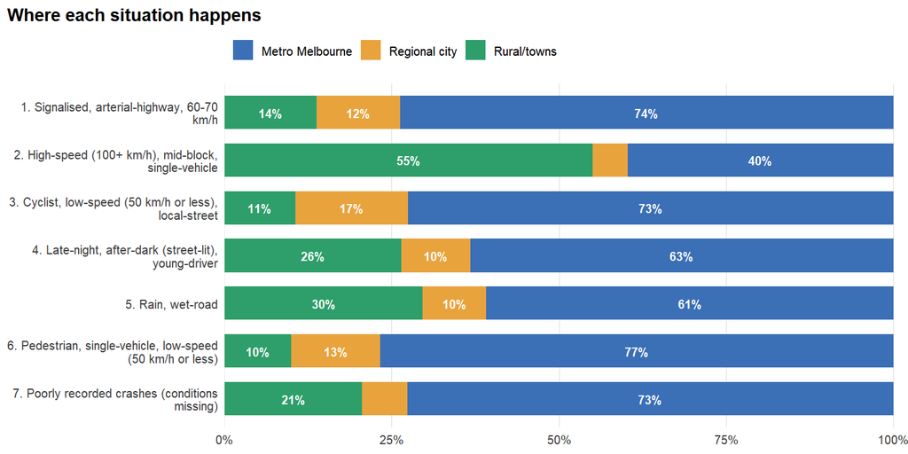

“Over-represented” compares a situation’s share of crashes in a council area (LGAs with 300+ crashes) with its share statewide: x2.0 means twice as common as average.

| Situation | Most crashes in | Most over-represented in |
| --- | --- | --- |
| 2. High-speed (100+ km/h), mid-block, single-vehicle | Casey, Yarra Ranges, Brimbank | Towong (x3.6), Mansfield (x3.1), Strathbogie (x3.1) |
| 4. Late-night, after-dark (street-lit), young-driver | Hume, Casey, Melbourne | Hume (x1.4), Loddon (x1.4), Gannawarra (x1.4) |
| 1. Signalised, arterial-highway, 60-70 km/h | Casey, Geelong, Dandenong | Knox (x1.6), Kingston (x1.6), Maroondah (x1.5) |
| 6. Pedestrian, single-vehicle, low-speed (50 km/h or less) | Melbourne, Moreland, Geelong | Melbourne (x2.0), Port Phillip (x1.7), Glen Eira (x1.6) |
| 5. Rain, wet-road | Casey, Yarra Ranges, Melbourne | South Gippsland (x2.3), Yarra Ranges (x1.7), Baw Baw (x1.7) |
| 3. Cyclist, low-speed (50 km/h or less), local-street | Melbourne, Yarra, Geelong | Yarra (x2.3), Bayside (x1.9), Port Phillip (x1.9) |
| 7. Poorly recorded crashes (conditions missing) | Melbourne, Casey, Hume | Mansfield (x1.7), Murrindindi (x1.7), Yarra (x1.6) |

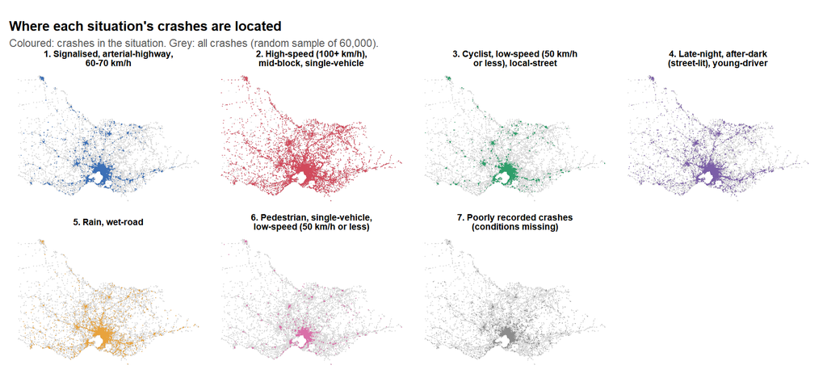

## 5.1 Interactive map

Use the boxes in the top-right corner to turn situations on and off. Every fatal crash is shown, larger and outlined, together with 8,000 randomly chosen other crashes. Click a point for details. The Shiny app (`shiny::runApp("app")`) has the full version with year, severity and region filters and story cards.

[interactive chart not shown]

# 6 Recommendations

These recommendations follow from the evidence above. The *measures* are well-established road-safety approaches; our analysis shows **where** they would address the most harm, not how well each one works. That would need evaluation data we don’t have.

1

#### Make high-speed rural roads more forgiving

1,174 deaths (36% of all), about 92 a year · 31.9 deaths per 1,000 crashes · 55% of these crashes are rural · most over-represented in Towong (x3.6), Mansfield (x3.1), Strathbogie (x3.1)

Protective infrastructure (barriers, rumble strips, sealed shoulders) and speed management on high-speed roads where single-vehicle crashes cluster.

Who could act: Department of Transport and Planning

2

#### Target night-time driving, especially by young drivers

731 deaths (23% of all) · 28.1 deaths per 1,000 crashes · a driver or rider aged 16-25 involved in nearly half

Night-time conditions in graduated licensing, better lighting at night-time crash locations, and enforcement focused on evening and late-night hours.

Who could act: Licensing authority Road-safety campaigns Victoria Police

3

#### Keep protecting pedestrians in the inner city

403 deaths · 27.4 deaths per 1,000 crashes · concentrated in Melbourne (x2.0), Port Phillip (x1.7), Glen Eira (x1.6)

Lower speeds and safer crossings where pedestrians and traffic mix.

Who could act: Local councils Department of Transport and Planning

4

#### Treat the roads where rain turns deadly

283 deaths · 15.4 deaths per 1,000 crashes · over-represented in South Gippsland (x2.3), Yarra Ranges (x1.7), Baw Baw (x1.7)

Skid-resistant surfacing and wet-weather warnings on the most affected roads.

Who could act: Department of Transport and Planning Local councils

5

#### Record every crash fully

7% of crashes have weather, surface or speed zone missing · they are the least severe, so minor crashes are documented least

Make weather, surface and speed zone mandatory in police crash reports, so future analysis isn’t biased toward serious crashes.

Who could act: Victoria Police

**The scale of the prize.** Every **10% reduction in deaths in the high-speed rural situation alone would mean about 9 fewer people killed each year**. That is simple arithmetic on the averages above, not a forecast.

# 7 How we did it

## 7.1 Data

The Victorian Crash Data release has nine linked tables. We joined them in R (`R/01_prepare.R`) into one row per crash: the accident record, the location, the most adverse weather and road surface, flags for the vehicles involved (motorcycle, bicycle, heavy vehicle, the oldest vehicle’s age, the strictest traffic control) and flags for the people involved (pedestrian, driver or rider aged 16-25 or 70+). The raw data is 168 MB and runs in R on a laptop in a few minutes; Hadoop was not needed. Missing values were kept as “Unknown” rather than dropped. That decision revealed the poorly-recorded situation.

## 7.2 Grouping crashes into situations

| Condition | Categories |
| --- | --- |
| Time of day | Night (0-5) (6%), Morning peak (6-9) (19%), Midday (10-14) (29%), Afternoon peak (15-18) (31%), Evening (19-23) (14%) |
| Day | Weekday (74%), Weekend (26%) |
| Light | Dark, street lit (15%), Dark, unlit (7%), Daylight (67%), Dusk/dawn (9%), Unknown (3%) |
| Speed zone | 50 km/h or less (23%), 60-70 km/h (39%), 80-90 km/h (15%), 100-110 km/h (15%), Unknown (7%) |
| Road geometry | Cross intersection (23%), Mid-block (52%), Other/unknown (3%), T intersection (23%) |
| Road class | Arterial highway (17%), Arterial road (36%), Freeway (8%), Local road (34%), Unknown (5%) |
| Traffic control | Signals (18%), Roundabout (4%), Give-way/stop sign (11%), None/other (67%) |
| Weather | Clear (78%), Other adverse (2%), Rain/snow (10%), Unknown (10%) |
| Road surface | Dry (78%), Unknown (6%), Wet/slippery (15%) |
| Vehicles involved | 1 vehicle (33%), 2 vehicles (56%), 3+ vehicles (11%) |
| Pedestrian involved | No (91%), Yes (9%) |
| Motorcycle involved | No (86%), Yes (14%) |
| Bicycle involved | No (90%), Yes (10%) |
| Heavy vehicle involved | No (95%), Yes (5%) |
| Driver/rider aged 16-25 | No (69%), Yes (31%) |
| Driver/rider aged 70+ | No (89%), Yes (11%) |
| Oldest vehicle 15+ years | No (61%), Yes (35%), Unknown (5%) |

Because the conditions are categories, not numbers, we used **Multiple Correspondence Analysis (MCA)**, the categorical version of PCA, to turn them into 7 numeric dimensions. We then grouped the crashes with **k-means**. The official category, accident type, severity and location were deliberately left out, so the comparisons in Sections 3 and 4 are fair tests rather than circular ones.

We tested 4 to 14 groups and chose 7. To be chosen, a solution had to come back almost identically from different random starts and from different halves of the data. Among the stable solutions, 7 gave the best-separated groups while still separating pedestrian, cyclist, night-time and wet-weather crashes. We also prototyped **Gower distance + PAM**, but its groups changed from sample to sample, so we only used it as a cross-check.

| Check | Result |
| --- | --- |
| Same groups from different random starts (ARI, 1 = identical) | 1.00 |
| Same groups from different halves of the data (ARI) | 0.96 |
| Separation between groups (silhouette, -1 to 1) | 0.11 |

The groups are very **stable** but not sharply **separated**. Crashes don’t fall into perfectly distinct types, because most share common conditions (daylight, dry road, weekday). The situations are best read as reliable regions of a continuum, so we interpret their overall profiles, not individual crash assignments.

## 7.3 Comparing with the official categories

We compared situations with DCA groups using cross-tables, the adjusted Rand index and normalised mutual information, and tested whether the situation adds predictive information about fatal crashes using logistic regression and a likelihood-ratio test (`R/03_compare_dca.R`). The stories in Section 4 are generated in R from each situation’s statistics and from a real crash record (`R/04_profile_stories.R`).

# 8 Limitations

- **No traffic volumes.** We know where people died, not how many trips were made. A situation with many deaths may partly reflect a lot of driving. Deaths *per crash* (used throughout) is not affected by this.
- **Recommendations show where, not what works.** The analysis identifies where harm is concentrated. Choosing between measures needs evaluation studies.
- **Situations depend on the conditions we chose.** A different set of conditions would give somewhat different groups. We explain every exclusion above.
- **Groups overlap.** They are stable but not sharply separated (silhouette 0.11).
- **Injury crashes only.** Crashes with only property damage aren’t in the data.
- **Recording gaps.** 7% of crashes have key conditions missing, mostly minor crashes.

# 9 Conclusion

Victoria’s official crash categories describe **how** crashes happen. This project shows that **the situation a crash happens in decides how likely it is to kill someone**, and that the official categories hide it. Within one category the death rate varied 24-fold depending on the situation.

The most common crashes, at city intersections, are not the most deadly. **High-speed rural roads and night-time driving account for 59% of the 3,244 deaths in the data** from only 35% of crashes. If road-safety effort follows crash counts, it is aimed at the wrong places. If it follows deaths by situation, it can be aimed where it saves the most lives.

# Reproducing this report

```
Rscript run_all.R        # runs R/01-04 and renders this report (about 3 minutes)
shiny::runApp("app")     # interactive map
```